# Task 4: Naples Reef (January 2010) purple urchins

Anna Zauner

10/24/2021

# Overview

This task utilizes data from Naples Reef along the Santa Barbara coast in 2010, to explore the mean size in diameter (cm) of purple urchins in the control group (no giant kelp removal) and the annual group (annual giant kelp removal).

**Data citation**: Reed, D. 2020. SBC LTER: Reef: Long-term experiment: Kelp removal: Urchin size frequency distribution ver 20. Environmental Data Initiative. https://doi.org/10.6073/pasta/5a1e9ef03aa47bd2225c0bb98a02a63b.

# Set up

```r
knitr::opts_chunk$set(echo = TRUE, message = FALSE, warning = FALSE)

# Attach packages
library(tidyverse)
library(dplyr)
library(janitor)
library(here)
library(kableExtra)
library(lubridate)
library(effsize)
```

# Read in the data

Read in data using `read_csv` and cleaned data with `clean_names()`

```r
urchins_data <- read_csv(here("data", "urchins.csv")) %>%
  clean_names()
```

# Wrangle the data

Converted date to class “Date” with `lubridate()`, created new columns with dates formatted and just years. Then filtered to only include observations at Naples Reef for purple urchins in 2010,

```r
naples_reef_purple_2010 <- urchins_data %>%
  mutate(date = mdy(date)) %>%
  mutate(year = year(date)) %>%
  filter(site == "NAPL",
         year == 2010,
         common_name == "Purple Urchin")
```

# Exploratory data visualization

## Histogram

Created a faceted histogram to compare the sizes of the control (no giant kelp removal) and annual (annual giant kelp removal) treatments for the purple urchins at Naples in 2010.

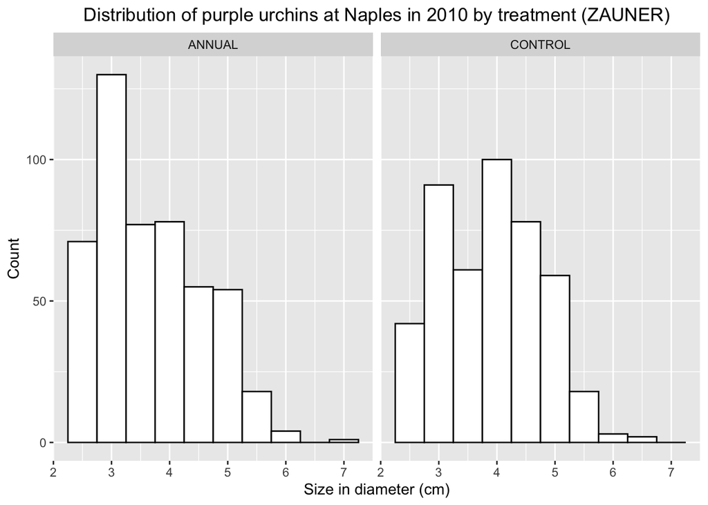

```r
ggplot(data = naples_reef_purple_2010, aes(x = size))+
  geom_histogram(color = "black", fill = "white", bins = 10)+
  facet_wrap(~ treatment)+
  labs(x = "Size in diameter (cm)",
       y = "Count",
       title = "Distribution of purple urchins at Naples in 2010 by treatment (ZAUNER)")+
  theme(plot.title = element_text(hjust = 0.5))
```

## QQ plot

Created a QQ plot to explore how the sample Quantiles compare to theoretical Quantiles for the mean size (cm) of purple urchins in Naples Reef in 2010.

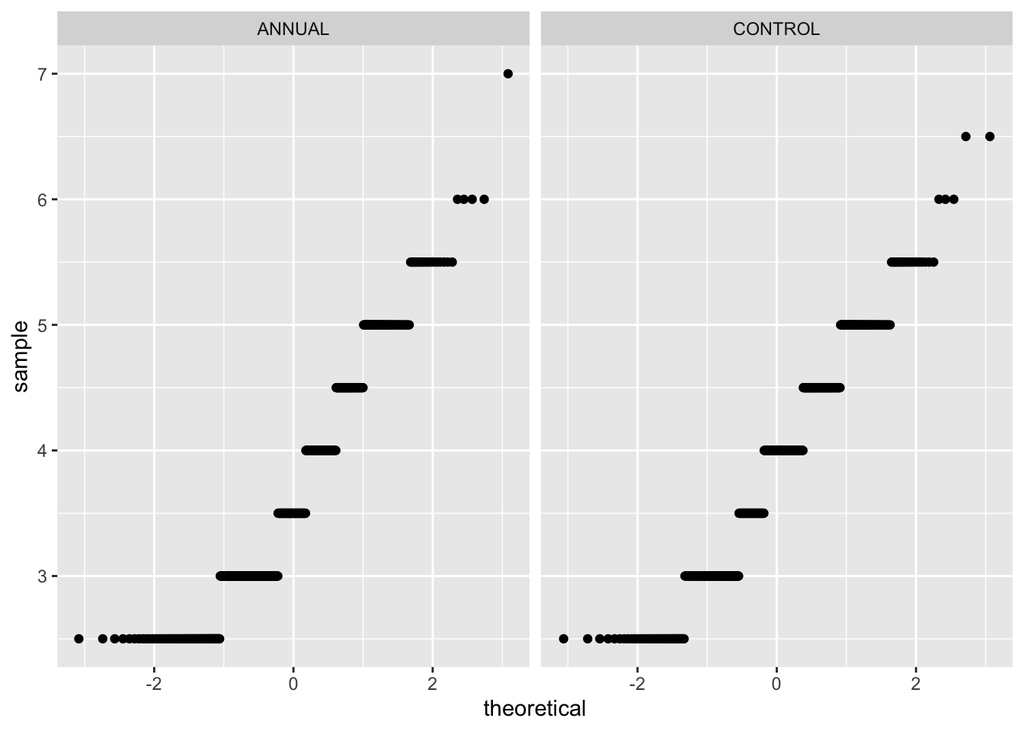

```r
ggplot(data = naples_reef_purple_2010, aes(sample = size))+
  geom_qq()+
  facet_wrap(~ treatment)
```

# Summary staistics

Created a table with statistics for purple urchins at Naples in 2010 based on treatment. (mean, median standard deviation, and sample size)

```r
naples_reef_purple_2010_table <- naples_reef_purple_2010 %>%
  group_by(treatment) %>%
  summarize(mean = mean(size),
            median = median(size),
            s_d = sd(size),
            sample_size = n()) %>%
  kable(caption = "Table 1: Summary statistics for purple urchin sizes (cm) at Naples in 2010",
        col.names = c("Treatment",
                      "Mean (cm)",
                      "Median (cm)",
                      "Standard deviation",
                      "Sample size"),
        digits = 1) %>%
  kable_minimal()

naples_reef_purple_2010_table
```

Table 1: Summary statistics for purple urchin sizes (cm) at Naples in 2010

| Treatment | Mean (cm) | Median (cm) | Standard deviation | Sample size |
| --- | --- | --- | --- | --- |
| ANNUAL | 3.7 | 3.5 | 0.9 | 488 |
| CONTROL | 3.9 | 4.0 | 0.9 | 454 |